# PMIM402J Classification

## Optimising random forest using hyperparameter tuning

**Q2c. (iii) What about some of the internal parameters specific to the classifier? Please explain how one of these parameters can affect accuracy.**

Optimising the mtry and ntree parameters (from default to 4 and 511 respectively) increased the accuracy from 84.78% to 85.65%, and the AUC from 0.85 to 0.86. Mtry is the number of variables randomly sampled at each split, whilst ntree is the number of trees to grow. Accuracy typically increases as the number of trees (ntree) increases because the results created from the randomised trees are averaged, reducing variance and improving accuracy/generalisability. However, after a certain number of trees the increase in accuracy becomes negligible. At this point it is not worth creating more trees as the increase in computational cost is not worthwhile. Looking at error plots can help to inform the optimal number of trees which will maximise accuracy and minimise computational cost.

```r
# Searching for optimal mtry value
set.seed(seed)
ytrain <- df.train.opt$class
ytest <- df.test.opt$class
xtrain <- df.train.opt %>% select(-class)
xtest <- df.test.opt %>% select(-class)
bestmtry <- tuneRF(xtrain, ytrain, stepFactor = 1.5, improve = 1e-5, ntree = 511)
```

```
## mtry = 4  OOB error = 20.14%
## Searching left ...
## mtry = 3     OOB error = 20.14%
## 0 1e-05
## Searching right ...
## mtry = 6     OOB error = 21.16%
## -0.05035971 1e-05
```

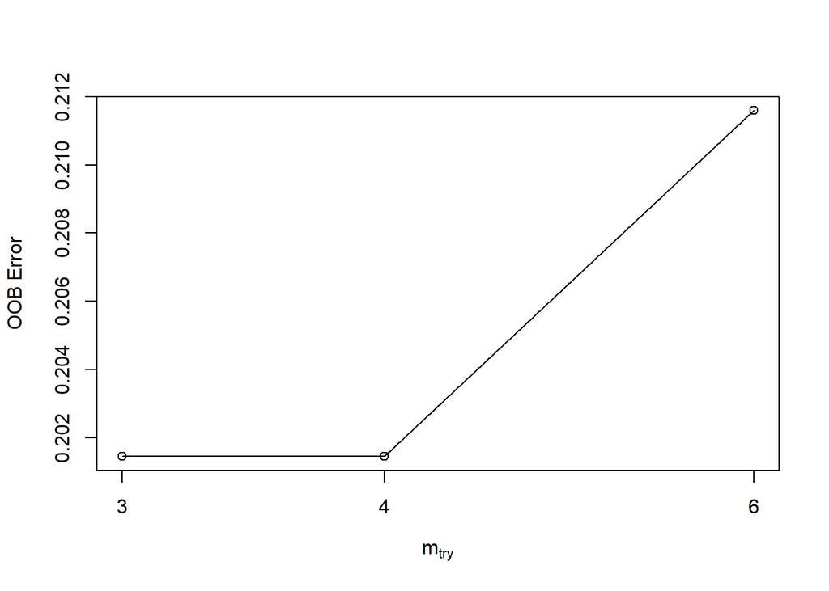

```r
print(bestmtry)
```

```
##       mtry  OOBError
## 3.OOB    3 0.2014493
## 4.OOB    4 0.2014493
## 6.OOB    6 0.2115942
```

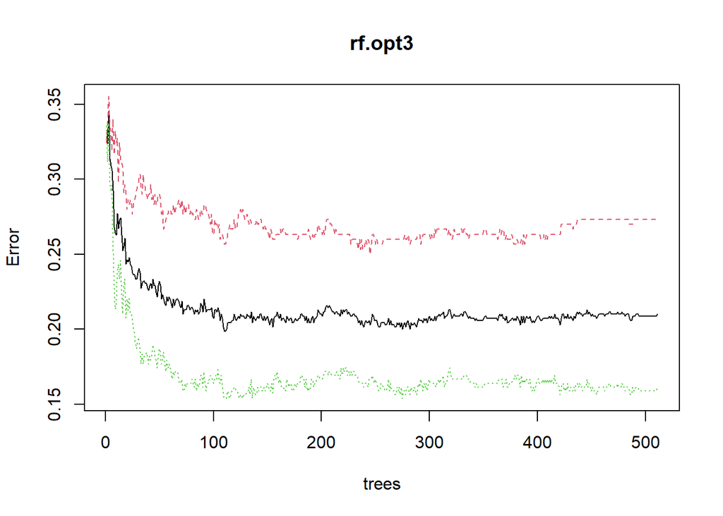

```r
# Training the model
rf.opt3 <- randomForest(class ~ cp + thalach + thal + oldpeak + age + exang +
                         perfusion + traponin + trestbps + slope + sex + restecg +
                         ca + drug + smoker + fam_hist, data = df.train.opt,
                        mtry = 4, ntree = 511)

# Ntree = 511 is a good value as the line on the error plot has flattened out
plot(rf.opt3)
```

```r
# Applying the algorithm to the test data
preds.opt3 <- predict(rf.opt3, df.test.opt, type = "response")

# Creating a confusion matrix
cm.opt3 <- table(predicted = preds.opt3, truth = df.test.opt$class)
cm.opt3
```

```
##          truth
## predicted   0   1
##         0  91  13
##         1  20 106
```

```r
# Checking accuracy
paste0("The accuracy is ", round(((cm.opt3[1,1] + cm.opt3[2,2]) / nrow(df.test.opt)) * 100, 2), "%.")
```

```
## [1] "The accuracy is 85.65%."
```

```r
# Checking sensitivity
paste0("The sensitivity is ", round((cm.opt3[2, 2] / (cm.opt3[2, 2] + cm.opt3[2, 1]) * 100), 2), "%.")
```

```
## [1] "The sensitivity is 84.13%."
```

```r
# Checking specificity
paste0("The specificity is ", round((cm.opt3[1, 1] / (cm.opt3[1, 1] + cm.opt3[1, 2]) * 100), 2), "%.")
```

```
## [1] "The specificity is 87.5%."
```

```r
# ROC analysis
res.opt3 <- roc(class ~ as.numeric(preds.opt3), data = df.test.opt)
res.opt3$auc
```

```
## Area under the curve: 0.8553
```

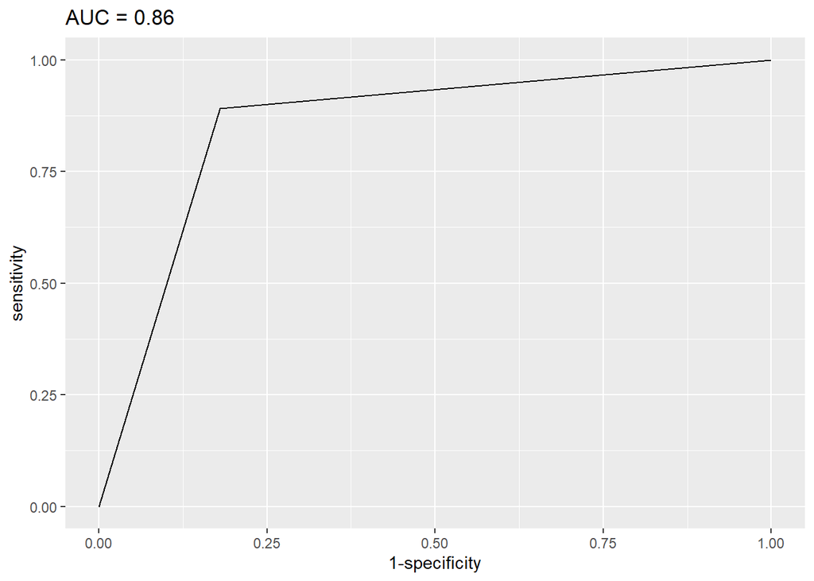

```r
ggroc(res.opt3, legacy.axes = TRUE) +
  labs(title = paste0("AUC = ", round(res.opt3$auc, 2)))
```

**Q2d. In general, a classifier is only as good as the data it is trained on. Please comment on what is needed from training data to train a good classifier. How can utilizing classifiers help feed back into healthcare settings with regards to data collection?**

The most important aspect of training data used for classification is that it must be accurately labelled so that the model is actually being trained to classify the data into the correct categories. The data should also be diverse and representative so that the model is effective in classifying future real-world data. Larger training datasets (e.g. 1000 rows rather than 100) typically create models with better accuracy as there are a wider range of scenarios captured, linking to this need for diversity and representativeness. It should also be ensured that training data is clean before being used to train a model, as missing or messy data would produce a greater number of incorrect predictions and therefore a less accurate model.

Utilising classifiers can feed back into healthcare settings’ data collection by streamlining the data collection process, reducing the time and resources (such as computational cost) spent. Using the example of heart disease, classifiers can help discover correlations between certain variables or determine which are the most important predictors of developing heart disease - this means collection of these data can be prioritised in an environment which is often hectic and which otherwise may have been left out, evident in how NAs are not uncommon amongst healthcare data.